# ETM 58D Business Analytics Project

###Hour 5

```r
lin_reg_h5 <- train(production ~ .,
                    data = weather_production_train_h5 %>% select(-date.x, -hour.x),
                    method = "lm",
                    trControl = fitControl,
                    tuneGrid = expand.grid(intercept = T),
                    tuneLength = 5)

dec_tree_h5 <- train(production ~ .,
                     data = weather_production_train_h5 %>% select(-date.x, -hour.x),
                     method = "rpart",
                     trControl = fitControl,
                     tuneGrid = expand.grid(cp = 0.01524276),
                     tuneLength = 6)

rand_forest_h5 <- train(production ~ .,
                        data = weather_production_train_h5 %>% select(-date.x, -hour.x),
                        method = "ranger",
                        trControl = fitControl,
                        num.trees = 50,
                        tuneGrid = expand.grid(mtry = 52, splitrule = "extratrees", min.node.size = 5),
                        importance = "impurity")

glmnet_h5 <- train(production ~ .,
                   data = weather_production_train_h5 %>% select(-date.x, -hour.x),
                   method = "glmnet",
                   trControl = fitControl,
                   tuneGrid = expand.grid(alpha = 0.55, lambda = 0.2097799),
                   tuneLenght= 5)

results = resamples(list(Linear_Regression = lin_reg_h5, Decision_Tree = dec_tree_h5, Random_Forest = rand_forest_h5, GLMNET = glmnet_h5))
summary(results)
```

```
##
## Call:
## summary.resamples(object = results)
##
## Models: Linear_Regression, Decision_Tree, Random_Forest, GLMNET
## Number of resamples: 25
##
## MAE
##                          Min.     1st Qu.      Median        Mean     3rd Qu.
## Linear_Regression 0.019035389 0.023129562 0.024853149 0.024472882 0.026304798
## Decision_Tree     0.008189347 0.010964858 0.011593207 0.012106555 0.013505386
## Random_Forest     0.005123016 0.007573147 0.008264491 0.008650263 0.009699196
## GLMNET            0.049207092 0.051761397 0.053569151 0.053608340 0.054231814
##                         Max. NA's
## Linear_Regression 0.02983075    0
## Decision_Tree     0.01745927    0
## Random_Forest     0.01192980    0
## GLMNET            0.05855237    0
##
## RMSE
##                         Min.    1st Qu.     Median       Mean    3rd Qu.
## Linear_Regression 0.02407872 0.03272096 0.03398539 0.03482255 0.03714910
## Decision_Tree     0.01755403 0.02277772 0.02690713 0.02656977 0.02793224
## Random_Forest     0.01075369 0.01719183 0.01918812 0.01916452 0.02147117
## GLMNET            0.06231863 0.06507528 0.06854422 0.06881215 0.07058887
##                         Max. NA's
## Linear_Regression 0.04574533    0
## Decision_Tree     0.03832993    0
## Random_Forest     0.02763525    0
## GLMNET            0.07975285    0
##
## Rsquared
##                        Min.   1st Qu.    Median      Mean   3rd Qu.      Max.
## Linear_Regression 0.5925876 0.7474132 0.7627429 0.7579132 0.7993174 0.8832637
## Decision_Tree     0.7408704 0.8452957 0.8665283 0.8576124 0.8828979 0.9488225
## Random_Forest     0.8013744 0.9022488 0.9203148 0.9210769 0.9417730 0.9794356
## GLMNET                   NA        NA        NA       NaN        NA        NA
##                   NA's
## Linear_Regression    0
## Decision_Tree        0
## Random_Forest        0
## GLMNET              25
```

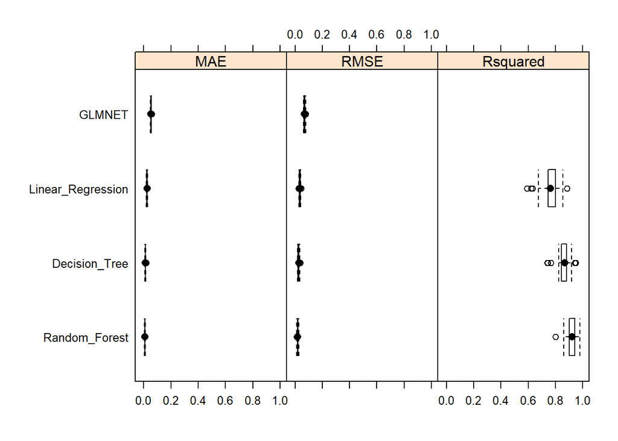

```r
bwplot(results)
```

###Hour 6

```r
lin_reg_h6 <- train(production ~ .,
                    data = weather_production_train_h6 %>% select(-date.x, -hour.x),
                    method = "lm",
                    trControl = fitControl,
                    tuneGrid = expand.grid(intercept = T),
                    tuneLength = 5)

dec_tree_h6 <- train(production ~ .,
                     data = weather_production_train_h6 %>% select(-date.x, -hour.x),
                     method = "rpart",
                     trControl = fitControl,
                     tuneGrid = expand.grid(cp = 0.01524276),
                     tuneLength = 6)

rand_forest_h6 <- train(production ~ .,
                        data = weather_production_train_h6 %>% select(-date.x, -hour.x),
                        method = "ranger",
                        trControl = fitControl,
                        num.trees = 50,
                        tuneGrid = expand.grid(mtry = 52, splitrule = "extratrees", min.node.size = 5),
                        importance = "impurity")

glmnet_h6 <- train(production ~ .,
                   data = weather_production_train_h6 %>% select(-date.x, -hour.x),
                   method = "glmnet",
                   trControl = fitControl,
                   tuneGrid = expand.grid(alpha = 0.55, lambda = 0.2097799),
                   tuneLenght= 5)

results = resamples(list(Linear_Regression = lin_reg_h6, Decision_Tree = dec_tree_h6, Random_Forest = rand_forest_h6, GLMNET = glmnet_h6))
summary(results)
```

```
##
## Call:
## summary.resamples(object = results)
##
## Models: Linear_Regression, Decision_Tree, Random_Forest, GLMNET
## Number of resamples: 25
##
## MAE
##                        Min.   1st Qu.    Median      Mean   3rd Qu.      Max.
## Linear_Regression 0.4076242 0.4779227 0.5212843 0.5253563 0.5482928 0.6562004
## Decision_Tree     0.3210443 0.3636010 0.4034552 0.4260776 0.4679683 0.7215854
## Random_Forest     0.2065158 0.2337801 0.2630112 0.2675567 0.2936824 0.3663526
## GLMNET            0.4798054 0.5527712 0.6406834 0.6226822 0.6801797 0.7603066
##                   NA's
## Linear_Regression    0
## Decision_Tree        0
## Random_Forest        0
## GLMNET               0
##
## RMSE
##                        Min.   1st Qu.    Median      Mean   3rd Qu.      Max.
## Linear_Regression 0.5719744 0.6745879 0.7736082 0.7789904 0.8847738 0.9909345
## Decision_Tree     0.4690150 0.5522443 0.6195351 0.7012622 0.7698890 1.3423904
## Random_Forest     0.3360895 0.4456907 0.4917870 0.5167291 0.5764773 0.7845806
## GLMNET            0.7510208 0.8930962 1.0212605 0.9890720 1.0923121 1.1660797
##                   NA's
## Linear_Regression    0
## Decision_Tree        0
## Random_Forest        0
## GLMNET               0
##
## Rsquared
##                        Min.   1st Qu.    Median      Mean   3rd Qu.      Max.
## Linear_Regression 0.7320389 0.7790735 0.8158725 0.8229462 0.8639407 0.9112491
## Decision_Tree     0.5913076 0.8082792 0.8819286 0.8551383 0.9137628 0.9493753
## Random_Forest     0.8528670 0.9063164 0.9314986 0.9241929 0.9493161 0.9632097
## GLMNET            0.6200581 0.7162148 0.7323174 0.7301411 0.7529191 0.8210444
##                   NA's
## Linear_Regression    0
## Decision_Tree        0
## Random_Forest        0
## GLMNET               0
```

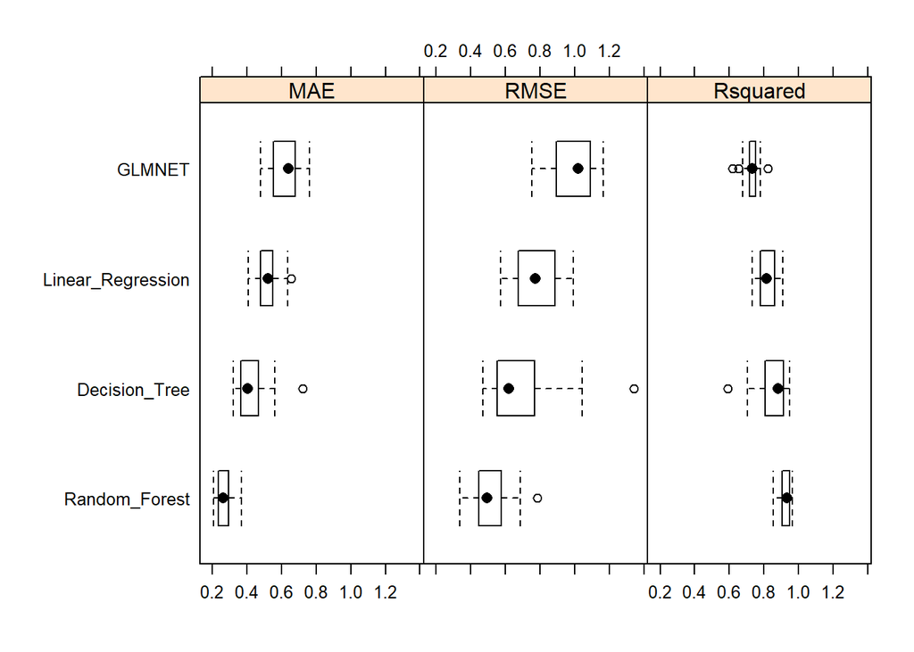

```r
bwplot(results)
```

###Hour 7

```r
lin_reg_h7 <- train(production ~ .,
                    data = weather_production_train_h7 %>% select(-date.x, -hour.x),
                    method = "lm",
                    trControl = fitControl,
                    tuneGrid = expand.grid(intercept = T),
                    tuneLength = 5)

dec_tree_h7 <- train(production ~ .,
                     data = weather_production_train_h7 %>% select(-date.x, -hour.x),
                     method = "rpart",
                     trControl = fitControl,
                     tuneGrid = expand.grid(cp = 0.01524276),
                     tuneLength = 6)

rand_forest_h7 <- train(production ~ .,
                        data = weather_production_train_h7 %>% select(-date.x, -hour.x),
                        method = "ranger",
                        trControl = fitControl,
                        num.trees = 50,
                        tuneGrid = expand.grid(mtry = 52, splitrule = "extratrees", min.node.size = 5),
                        importance = "impurity")

glmnet_h7 <- train(production ~ .,
                   data = weather_production_train_h7 %>% select(-date.x, -hour.x),
                   method = "glmnet",
                   trControl = fitControl,
                   tuneGrid = expand.grid(alpha = 0.55, lambda = 0.2097799),
                   tuneLenght= 5)

results = resamples(list(Linear_Regression = lin_reg_h7, Decision_Tree = dec_tree_h7, Random_Forest = rand_forest_h7, GLMNET = glmnet_h7))
summary(results)
```

```
##
## Call:
## summary.resamples(object = results)
##
## Models: Linear_Regression, Decision_Tree, Random_Forest, GLMNET
## Number of resamples: 25
##
## MAE
##                        Min.  1st Qu.   Median     Mean  3rd Qu.     Max. NA's
## Linear_Regression 1.3622462 1.520422 1.649648 1.636649 1.739143 1.988221    0
## Decision_Tree     1.6240299 1.951884 2.141274 2.142202 2.313533 2.723642    0
## Random_Forest     0.9489045 1.139702 1.226608 1.244477 1.351042 1.738009    0
## GLMNET            1.2839053 1.459590 1.536048 1.589396 1.730038 1.969939    0
##
## RMSE
##                       Min.  1st Qu.   Median     Mean  3rd Qu.     Max. NA's
## Linear_Regression 1.725272 2.126660 2.262310 2.271594 2.378071 2.859148    0
## Decision_Tree     2.146509 2.700553 2.975284 2.969760 3.272681 3.944781    0
## Random_Forest     1.279580 1.741160 1.942045 1.945457 2.088002 2.767060    0
## GLMNET            1.634838 2.018112 2.149468 2.172357 2.298605 2.929915    0
##
## Rsquared
##                        Min.   1st Qu.    Median      Mean   3rd Qu.      Max.
## Linear_Regression 0.9087452 0.9300567 0.9386285 0.9378741 0.9453765 0.9677306
## Decision_Tree     0.8166327 0.8686723 0.8987698 0.8907621 0.9123252 0.9443171
## Random_Forest     0.9135147 0.9469713 0.9553938 0.9542397 0.9661159 0.9826332
## GLMNET            0.8993111 0.9302125 0.9438750 0.9417587 0.9514764 0.9722791
##                   NA's
## Linear_Regression    0
## Decision_Tree        0
## Random_Forest        0
## GLMNET               0
```

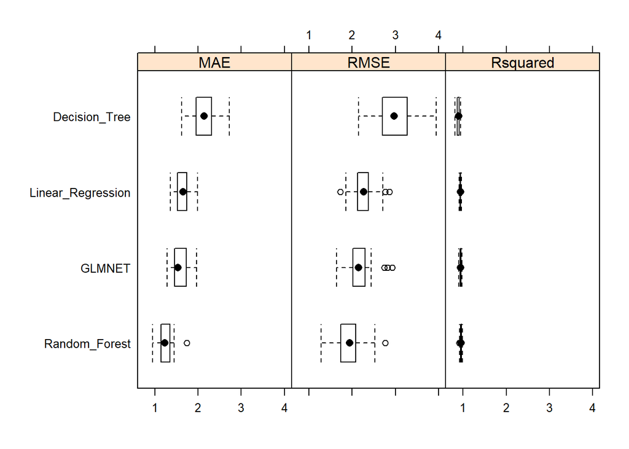

```r
bwplot(results)
```

###Hour 8

```r
lin_reg_h8 <- train(production ~ .,
                    data = weather_production_train_h8 %>% select(-date.x, -hour.x),
                    method = "lm",
                    trControl = fitControl,
                    tuneGrid = expand.grid(intercept = T),
                    tuneLength = 5)

dec_tree_h8 <- train(production ~ .,
                     data = weather_production_train_h8 %>% select(-date.x, -hour.x),
                     method = "rpart",
                     trControl = fitControl,
                     tuneGrid = expand.grid(cp = 0.01524276),
                     tuneLength = 6)

rand_forest_h8 <- train(production ~ .,
                        data = weather_production_train_h8 %>% select(-date.x, -hour.x),
                        method = "ranger",
                        trControl = fitControl,
                        num.trees = 50,
                        tuneGrid = expand.grid(mtry = 52, splitrule = "extratrees", min.node.size = 5),
                        importance = "impurity")

glmnet_h8 <- train(production ~ .,
                   data = weather_production_train_h8 %>% select(-date.x, -hour.x),
                   method = "glmnet",
                   trControl = fitControl,
                   tuneGrid = expand.grid(alpha = 0.55, lambda = 0.2097799),
                   tuneLenght= 5)

results = resamples(list(Linear_Regression = lin_reg_h8, Decision_Tree = dec_tree_h8, Random_Forest = rand_forest_h8, GLMNET = glmnet_h8))
summary(results)
```

```
##
## Call:
## summary.resamples(object = results)
##
## Models: Linear_Regression, Decision_Tree, Random_Forest, GLMNET
## Number of resamples: 25
##
## MAE
##                       Min.  1st Qu.   Median     Mean  3rd Qu.     Max. NA's
## Linear_Regression 2.255727 2.662890 2.894247 2.944423 3.152668 3.573189    0
## Decision_Tree     2.755908 3.110776 3.287016 3.329128 3.516353 3.974860    0
## Random_Forest     1.782436 2.169781 2.283842 2.312648 2.444401 3.003992    0
## GLMNET            2.460604 2.894196 3.097471 3.108274 3.368866 3.823476    0
##
## RMSE
##                       Min.  1st Qu.   Median     Mean  3rd Qu.     Max. NA's
## Linear_Regression 3.085403 3.695645 3.895978 3.912901 4.181763 4.751202    0
## Decision_Tree     3.453468 3.966981 4.335154 4.353406 4.633294 5.308048    0
## Random_Forest     2.578168 3.173561 3.402335 3.449929 3.676618 4.453553    0
## GLMNET            3.253413 3.717529 3.962065 4.052352 4.496949 4.893038    0
##
## Rsquared
##                        Min.   1st Qu.    Median      Mean   3rd Qu.      Max.
## Linear_Regression 0.8766996 0.9110253 0.9189894 0.9186597 0.9294999 0.9508920
## Decision_Tree     0.8548716 0.8831650 0.9007398 0.8990258 0.9175850 0.9350075
## Random_Forest     0.8933837 0.9287125 0.9398034 0.9359860 0.9467716 0.9670740
## GLMNET            0.8772940 0.8957728 0.9136694 0.9129110 0.9279351 0.9436530
##                   NA's
## Linear_Regression    0
## Decision_Tree        0
## Random_Forest        0
## GLMNET               0
```

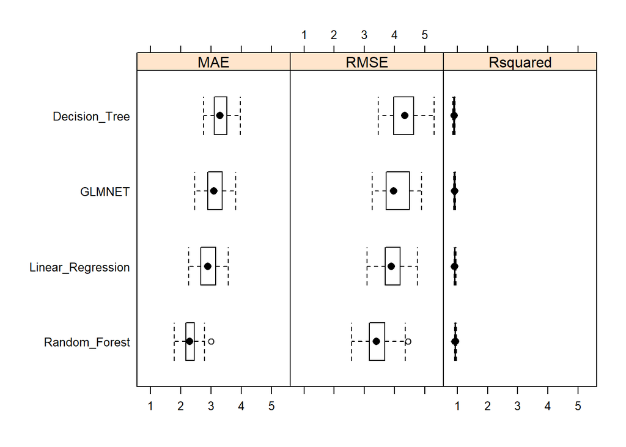

```r
bwplot(results)
```

###Hour 9

```r
lin_reg_h9 <- train(production ~ .,
                    data = weather_production_train_h9 %>% select(-date.x, -hour.x),
                    method = "lm",
                    trControl = fitControl,
                    tuneGrid = expand.grid(intercept = T),
                    tuneLength = 5)

dec_tree_h9 <- train(production ~ .,
                     data = weather_production_train_h9 %>% select(-date.x, -hour.x),
                     method = "rpart",
                     trControl = fitControl,
                     tuneGrid = expand.grid(cp = 0.01524276),
                     tuneLength = 6)

rand_forest_h9 <- train(production ~ .,
                        data = weather_production_train_h9 %>% select(-date.x, -hour.x),
                        method = "ranger",
                        trControl = fitControl,
                        num.trees = 50,
                        tuneGrid = expand.grid(mtry = 52, splitrule = "extratrees", min.node.size = 5),
                        importance = "impurity")

glmnet_h9 <- train(production ~ .,
                   data = weather_production_train_h9 %>% select(-date.x, -hour.x),
                   method = "glmnet",
                   trControl = fitControl,
                   tuneGrid = expand.grid(alpha = 0.55, lambda = 0.2097799),
                   tuneLenght= 5)

results = resamples(list(Linear_Regression = lin_reg_h9, Decision_Tree = dec_tree_h9, Random_Forest = rand_forest_h9, GLMNET = glmnet_h9))
summary(results)
```

```
##
## Call:
## summary.resamples(object = results)
##
## Models: Linear_Regression, Decision_Tree, Random_Forest, GLMNET
## Number of resamples: 25
##
## MAE
##                       Min.  1st Qu.   Median     Mean  3rd Qu.     Max. NA's
## Linear_Regression 2.263589 2.737065 2.980813 2.932606 3.182351 3.581627    0
## Decision_Tree     2.104807 2.646187 2.938318 2.915573 3.101985 3.918451    0
## Random_Forest     1.716245 2.043551 2.308826 2.333594 2.559964 2.828075    0
## GLMNET            2.247888 2.539197 2.817173 2.753226 2.868662 3.133670    0
##
## RMSE
##                       Min.  1st Qu.   Median     Mean  3rd Qu.     Max. NA's
## Linear_Regression 3.252257 3.952626 4.173035 4.253419 4.495729 5.556965    0
## Decision_Tree     2.958889 4.058492 4.433305 4.383451 4.718515 5.951690    0
## Random_Forest     2.950888 3.646578 3.948700 3.902867 4.168805 4.731943    0
## GLMNET            3.263768 3.917268 4.205398 4.131441 4.350666 4.726121    0
##
## Rsquared
##                        Min.   1st Qu.    Median      Mean   3rd Qu.      Max.
## Linear_Regression 0.8078683 0.8846873 0.9041110 0.8952445 0.9112022 0.9290568
## Decision_Tree     0.8067709 0.8676089 0.8918178 0.8869246 0.9089692 0.9524716
## Random_Forest     0.8594198 0.8918572 0.9125242 0.9108754 0.9296613 0.9523341
## GLMNET            0.8558749 0.8889503 0.8954508 0.9003249 0.9112711 0.9359893
##                   NA's
## Linear_Regression    0
## Decision_Tree        0
## Random_Forest        0
## GLMNET               0
```

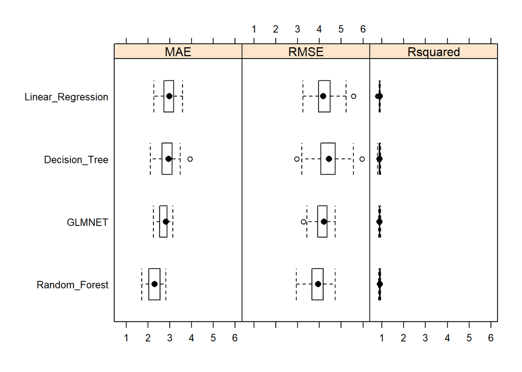

```r
bwplot(results)
```

###Hour 10

```r
lin_reg_h10 <- train(production ~ .,
                    data = weather_production_train_h10 %>% select(-date.x, -hour.x),
                    method = "lm",
                    trControl = fitControl,
                    tuneGrid = expand.grid(intercept = T),
                    tuneLength = 5)

dec_tree_h10 <- train(production ~ .,
                     data = weather_production_train_h10 %>% select(-date.x, -hour.x),
                     method = "rpart",
                     trControl = fitControl,
                     tuneGrid = expand.grid(cp = 0.01524276),
                     tuneLength = 6)

rand_forest_h10 <- train(production ~ .,
                        data = weather_production_train_h10 %>% select(-date.x, -hour.x),
                        method = "ranger",
                        trControl = fitControl,
                        num.trees = 50,
                        tuneGrid = expand.grid(mtry = 52, splitrule = "extratrees", min.node.size = 5),
                        importance = "impurity")

glmnet_h10 <- train(production ~ .,
                   data = weather_production_train_h10 %>% select(-date.x, -hour.x),
                   method = "glmnet",
                   trControl = fitControl,
                   tuneGrid = expand.grid(alpha = 0.55, lambda = 0.2097799),
                   tuneLenght= 5)

results = resamples(list(Linear_Regression = lin_reg_h10, Decision_Tree = dec_tree_h10, Random_Forest = rand_forest_h10, GLMNET = glmnet_h10))
summary(results)
```

```
##
## Call:
## summary.resamples(object = results)
##
## Models: Linear_Regression, Decision_Tree, Random_Forest, GLMNET
## Number of resamples: 25
##
## MAE
##                       Min.  1st Qu.   Median     Mean  3rd Qu.     Max. NA's
## Linear_Regression 1.713659 2.092197 2.291722 2.250718 2.383850 2.737405    0
## Decision_Tree     2.107793 2.686758 2.831861 2.795134 2.956536 3.245829    0
## Random_Forest     1.356663 1.550338 1.757759 1.766855 1.902262 2.509193    0
## GLMNET            1.509684 1.785365 1.909064 1.913978 2.061778 2.268995    0
##
## RMSE
##                       Min.  1st Qu.   Median     Mean  3rd Qu.     Max. NA's
## Linear_Regression 2.668748 3.169322 3.462923 3.456070 3.740167 4.176032    0
## Decision_Tree     2.919705 3.833286 4.040600 4.096875 4.448761 5.223788    0
## Random_Forest     2.270162 2.682868 2.973074 3.070484 3.337166 4.506689    0
## GLMNET            2.422145 3.054719 3.206755 3.234586 3.472265 3.728143    0
##
## Rsquared
##                        Min.   1st Qu.    Median      Mean   3rd Qu.      Max.
## Linear_Regression 0.8786693 0.9110983 0.9180217 0.9198151 0.9361671 0.9595576
## Decision_Tree     0.8118469 0.8810051 0.8906330 0.8861158 0.9002451 0.9400568
## Random_Forest     0.8526950 0.9235543 0.9418347 0.9360172 0.9516181 0.9698449
## GLMNET            0.9033650 0.9156647 0.9291454 0.9286007 0.9387994 0.9585715
##                   NA's
## Linear_Regression    0
## Decision_Tree        0
## Random_Forest        0
## GLMNET               0
```

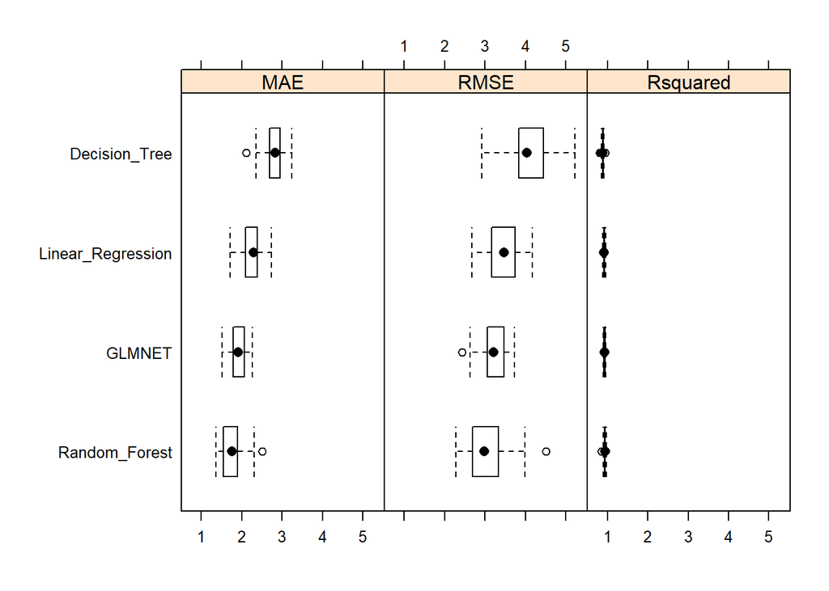

```r
bwplot(results)
```

###Hour 11

```r
lin_reg_h11 <- train(production ~ .,
                    data = weather_production_train_h11 %>% select(-date.x, -hour.x),
                    method = "lm",
                    trControl = fitControl,
                    tuneGrid = expand.grid(intercept = T),
                    tuneLength = 5)

dec_tree_h11 <- train(production ~ .,
                     data = weather_production_train_h11 %>% select(-date.x, -hour.x),
                     method = "rpart",
                     trControl = fitControl,
                     tuneGrid = expand.grid(cp = 0.01524276),
                     tuneLength = 6)

rand_forest_h11 <- train(production ~ .,
                        data = weather_production_train_h11 %>% select(-date.x, -hour.x),
                        method = "ranger",
                        trControl = fitControl,
                        num.trees = 50,
                        tuneGrid = expand.grid(mtry = 52, splitrule = "extratrees", min.node.size = 5),
                        importance = "impurity")

glmnet_h11 <- train(production ~ .,
                   data = weather_production_train_h11 %>% select(-date.x, -hour.x),
                   method = "glmnet",
                   trControl = fitControl,
                   tuneGrid = expand.grid(alpha = 0.55, lambda = 0.2097799),
                   tuneLenght= 5)

results = resamples(list(Linear_Regression = lin_reg_h11, Decision_Tree = dec_tree_h11, Random_Forest = rand_forest_h11, GLMNET = glmnet_h11))
summary(results)
```

```
##
## Call:
## summary.resamples(object = results)
##
## Models: Linear_Regression, Decision_Tree, Random_Forest, GLMNET
## Number of resamples: 25
##
## MAE
##                       Min.  1st Qu.   Median     Mean  3rd Qu.     Max. NA's
## Linear_Regression 1.566431 2.113224 2.365603 2.365245 2.499750 3.036342    0
## Decision_Tree     1.569654 2.345316 2.704890 2.696646 3.015878 4.017694    0
## Random_Forest     1.646296 1.910968 2.077379 2.085780 2.238333 2.572051    0
## GLMNET            1.729721 1.847230 2.140237 2.064324 2.270122 2.444275    0
##
## RMSE
##                       Min.  1st Qu.   Median     Mean  3rd Qu.     Max. NA's
## Linear_Regression 2.477944 3.376020 4.004586 3.872809 4.243917 5.032094    0
## Decision_Tree     2.296042 3.898832 4.210560 4.349102 4.843640 6.271147    0
## Random_Forest     2.837394 3.235748 3.699006 3.688065 4.034583 4.751440    0
## GLMNET            2.591132 3.241131 3.621052 3.529256 3.923642 4.442155    0
##
## Rsquared
##                        Min.   1st Qu.    Median      Mean   3rd Qu.      Max.
## Linear_Regression 0.7885649 0.8538809 0.8739132 0.8800046 0.9144914 0.9539376
## Decision_Tree     0.7076017 0.8301619 0.8512775 0.8475034 0.8868351 0.9670334
## Random_Forest     0.7988033 0.8564154 0.9038808 0.8912161 0.9206904 0.9454768
## GLMNET            0.8492008 0.8804981 0.8974176 0.9002710 0.9192745 0.9639664
##                   NA's
## Linear_Regression    0
## Decision_Tree        0
## Random_Forest        0
## GLMNET               0
```

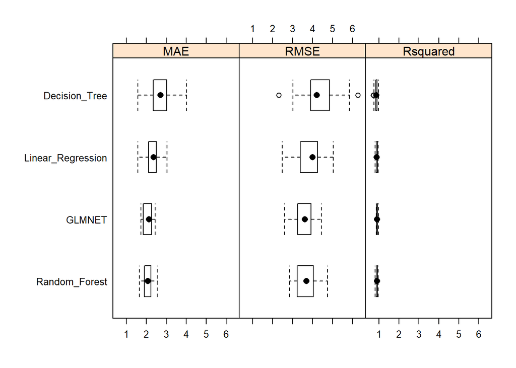

```r
bwplot(results)
```

###Hour 12

```r
lin_reg_h12 <- train(production ~ .,
                    data = weather_production_train_h12 %>% select(-date.x, -hour.x),
                    method = "lm",
                    trControl = fitControl,
                    tuneGrid = expand.grid(intercept = T),
                    tuneLength = 5)

dec_tree_h12 <- train(production ~ .,
                     data = weather_production_train_h12 %>% select(-date.x, -hour.x),
                     method = "rpart",
                     trControl = fitControl,
                     tuneGrid = expand.grid(cp = 0.01524276),
                     tuneLength = 6)

rand_forest_h12 <- train(production ~ .,
                        data = weather_production_train_h12 %>% select(-date.x, -hour.x),
                        method = "ranger",
                        trControl = fitControl,
                        num.trees = 50,
                        tuneGrid = expand.grid(mtry = 52, splitrule = "extratrees", min.node.size = 5),
                        importance = "impurity")

glmnet_h12 <- train(production ~ .,
                   data = weather_production_train_h12 %>% select(-date.x, -hour.x),
                   method = "glmnet",
                   trControl = fitControl,
                   tuneGrid = expand.grid(alpha = 0.55, lambda = 0.2097799),
                   tuneLenght= 5)

results = resamples(list(Linear_Regression = lin_reg_h12, Decision_Tree = dec_tree_h12, Random_Forest = rand_forest_h12, GLMNET = glmnet_h12))
summary(results)
```

```
##
## Call:
## summary.resamples(object = results)
##
## Models: Linear_Regression, Decision_Tree, Random_Forest, GLMNET
## Number of resamples: 25
##
## MAE
##                       Min.  1st Qu.   Median     Mean  3rd Qu.     Max. NA's
## Linear_Regression 1.621041 1.898315 2.135236 2.067395 2.213496 2.481613    0
## Decision_Tree     2.349868 2.531522 2.750716 2.750035 2.917049 3.289016    0
## Random_Forest     1.454324 1.879407 1.984898 1.989004 2.146252 2.476310    0
## GLMNET            1.348361 1.685726 1.768819 1.773750 1.888354 2.153632    0
##
## RMSE
##                       Min.  1st Qu.   Median     Mean  3rd Qu.     Max. NA's
## Linear_Regression 2.269493 2.952764 3.085463 3.248042 3.709076 4.373016    0
## Decision_Tree     3.173173 3.626153 3.848478 3.911878 4.226734 4.725045    0
## Random_Forest     1.944787 2.969348 3.332853 3.269850 3.626905 4.254983    0
## GLMNET            2.226392 2.726013 2.902221 2.963385 3.204639 3.729193    0
##
## Rsquared
##                        Min.   1st Qu.    Median      Mean   3rd Qu.      Max.
## Linear_Regression 0.8266396 0.8764460 0.9188349 0.9036657 0.9229359 0.9537945
## Decision_Tree     0.8030858 0.8475668 0.8618157 0.8633377 0.8829454 0.9145853
## Random_Forest     0.8378745 0.8902162 0.8961423 0.9035102 0.9284104 0.9681046
## GLMNET            0.8819094 0.9157258 0.9263179 0.9218635 0.9367024 0.9513558
##                   NA's
## Linear_Regression    0
## Decision_Tree        0
## Random_Forest        0
## GLMNET               0
```

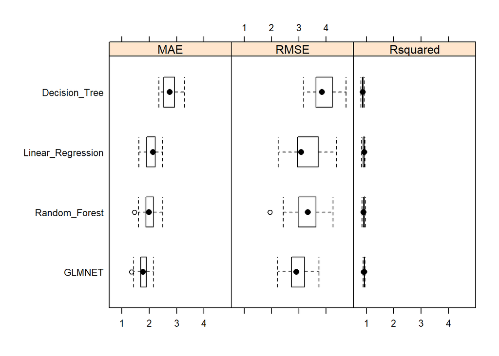

```r
bwplot(results)
```

###Hour 13

```r
lin_reg_h13 <- train(production ~ .,
                    data = weather_production_train_h13 %>% select(-date.x, -hour.x),
                    method = "lm",
                    trControl = fitControl,
                    tuneGrid = expand.grid(intercept = T),
                    tuneLength = 5)

dec_tree_h13 <- train(production ~ .,
                     data = weather_production_train_h13 %>% select(-date.x, -hour.x),
                     method = "rpart",
                     trControl = fitControl,
                     tuneGrid = expand.grid(cp = 0.01524276),
                     tuneLength = 6)

rand_forest_h13 <- train(production ~ .,
                        data = weather_production_train_h13 %>% select(-date.x, -hour.x),
                        method = "ranger",
                        trControl = fitControl,
                        num.trees = 50,
                        tuneGrid = expand.grid(mtry = 52, splitrule = "extratrees", min.node.size = 5),
                        importance = "impurity")

glmnet_h13 <- train(production ~ .,
                   data = weather_production_train_h13 %>% select(-date.x, -hour.x),
                   method = "glmnet",
                   trControl = fitControl,
                   tuneGrid = expand.grid(alpha = 0.55, lambda = 0.2097799),
                   tuneLenght= 5)

results = resamples(list(Linear_Regression = lin_reg_h13, Decision_Tree = dec_tree_h13, Random_Forest = rand_forest_h13, GLMNET = glmnet_h13))
summary(results)
```

```
##
## Call:
## summary.resamples(object = results)
##
## Models: Linear_Regression, Decision_Tree, Random_Forest, GLMNET
## Number of resamples: 25
##
## MAE
##                       Min.  1st Qu.   Median     Mean  3rd Qu.     Max. NA's
## Linear_Regression 2.294129 2.474334 2.707314 2.645601 2.814916 3.030031    0
## Decision_Tree     2.539224 2.830650 3.064259 3.204395 3.629632 4.051606    0
## Random_Forest     1.738722 2.433362 2.559011 2.556942 2.735582 3.135401    0
## GLMNET            1.803419 2.044607 2.335557 2.273127 2.437407 2.719577    0
##
## RMSE
##                       Min.  1st Qu.   Median     Mean  3rd Qu.     Max. NA's
## Linear_Regression 3.221668 3.680034 3.954756 4.025928 4.329802 4.935709    0
## Decision_Tree     3.439645 4.069436 4.512536 4.616014 5.249381 6.016074    0
## Random_Forest     2.557728 3.506560 3.925513 3.925966 4.267463 5.061090    0
## GLMNET            2.369672 3.028491 3.681185 3.575882 3.906837 4.551964    0
##
## Rsquared
##                        Min.   1st Qu.    Median      Mean   3rd Qu.      Max.
## Linear_Regression 0.7779440 0.8443739 0.8678072 0.8613589 0.8765831 0.9185920
## Decision_Tree     0.6646282 0.7761249 0.8155425 0.8141800 0.8598590 0.9184541
## Random_Forest     0.7699498 0.8383225 0.8664177 0.8658714 0.8989656 0.9501185
## GLMNET            0.8053032 0.8652556 0.8912368 0.8884765 0.9222496 0.9561456
##                   NA's
## Linear_Regression    0
## Decision_Tree        0
## Random_Forest        0
## GLMNET               0
```

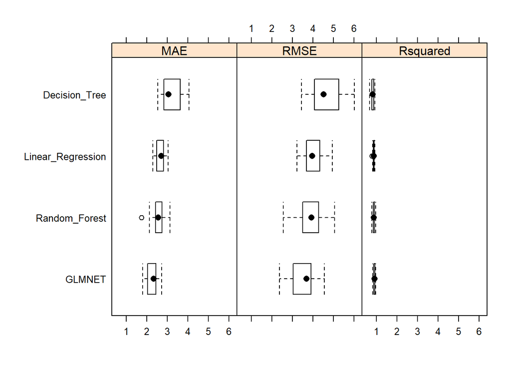

```r
bwplot(results)
```

###Hour 14

```r
lin_reg_h14 <- train(production ~ .,
                    data = weather_production_train_h14 %>% select(-date.x, -hour.x),
                    method = "lm",
                    trControl = fitControl,
                    tuneGrid = expand.grid(intercept = T),
                    tuneLength = 5)

dec_tree_h14 <- train(production ~ .,
                     data = weather_production_train_h14 %>% select(-date.x, -hour.x),
                     method = "rpart",
                     trControl = fitControl,
                     tuneGrid = expand.grid(cp = 0.01524276),
                     tuneLength = 6)

rand_forest_h14 <- train(production ~ .,
                        data = weather_production_train_h14 %>% select(-date.x, -hour.x),
                        method = "ranger",
                        trControl = fitControl,
                        num.trees = 50,
                        tuneGrid = expand.grid(mtry = 52, splitrule = "extratrees", min.node.size = 5),
                        importance = "impurity")

glmnet_h14 <- train(production ~ .,
                   data = weather_production_train_h14 %>% select(-date.x, -hour.x),
                   method = "glmnet",
                   trControl = fitControl,
                   tuneGrid = expand.grid(alpha = 0.55, lambda = 0.2097799),
                   tuneLenght= 5)

results = resamples(list(Linear_Regression = lin_reg_h14, Decision_Tree = dec_tree_h14, Random_Forest = rand_forest_h14, GLMNET = glmnet_h14))
summary(results)
```

```
##
## Call:
## summary.resamples(object = results)
##
## Models: Linear_Regression, Decision_Tree, Random_Forest, GLMNET
## Number of resamples: 25
##
## MAE
##                       Min.  1st Qu.   Median     Mean  3rd Qu.     Max. NA's
## Linear_Regression 2.571125 2.751409 2.858817 2.931346 3.134612 3.523970    0
## Decision_Tree     2.837882 3.192718 3.431866 3.421017 3.665270 3.881849    0
## Random_Forest     2.134964 2.556801 2.747066 2.748548 2.926459 3.381452    0
## GLMNET            2.290704 2.462847 2.614742 2.645399 2.791250 3.267547    0
##
## RMSE
##                       Min.  1st Qu.   Median     Mean  3rd Qu.     Max. NA's
## Linear_Regression 3.614318 4.101447 4.270583 4.384795 4.915367 5.148674    0
## Decision_Tree     3.999203 4.589413 4.785485 4.909707 5.242761 5.795320    0
## Random_Forest     3.225567 3.758656 4.277105 4.235776 4.587250 5.299144    0
## GLMNET            3.037091 3.694458 3.887217 4.030799 4.331014 5.530929    0
##
## Rsquared
##                        Min.   1st Qu.    Median      Mean   3rd Qu.      Max.
## Linear_Regression 0.7722975 0.8294197 0.8605363 0.8494621 0.8747172 0.9105408
## Decision_Tree     0.7318995 0.7789693 0.8057261 0.8100232 0.8427949 0.8703991
## Random_Forest     0.8000782 0.8351203 0.8538082 0.8593410 0.8922191 0.9230154
## GLMNET            0.7659121 0.8603435 0.8737981 0.8713255 0.9001087 0.9392148
##                   NA's
## Linear_Regression    0
## Decision_Tree        0
## Random_Forest        0
## GLMNET               0
```

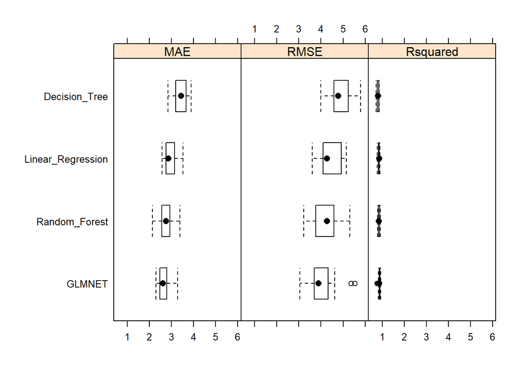

```r
bwplot(results)
```

###Hour 15

```r
lin_reg_h15 <- train(production ~ .,
                    data = weather_production_train_h15 %>% select(-date.x, -hour.x),
                    method = "lm",
                    trControl = fitControl,
                    tuneGrid = expand.grid(intercept = T),
                    tuneLength = 5)

dec_tree_h15 <- train(production ~ .,
                     data = weather_production_train_h15 %>% select(-date.x, -hour.x),
                     method = "rpart",
                     trControl = fitControl,
                     tuneGrid = expand.grid(cp = 0.01524276),
                     tuneLength = 6)

rand_forest_h15 <- train(production ~ .,
                        data = weather_production_train_h15 %>% select(-date.x, -hour.x),
                        method = "ranger",
                        trControl = fitControl,
                        num.trees = 50,
                        tuneGrid = expand.grid(mtry = 52, splitrule = "extratrees", min.node.size = 5),
                        importance = "impurity")

glmnet_h15 <- train(production ~ .,
                   data = weather_production_train_h15 %>% select(-date.x, -hour.x),
                   method = "glmnet",
                   trControl = fitControl,
                   tuneGrid = expand.grid(alpha = 0.55, lambda = 0.2097799),
                   tuneLenght= 5)

results = resamples(list(Linear_Regression = lin_reg_h15, Decision_Tree = dec_tree_h15, Random_Forest = rand_forest_h15, GLMNET = glmnet_h15))
summary(results)
```

```
##
## Call:
## summary.resamples(object = results)
##
## Models: Linear_Regression, Decision_Tree, Random_Forest, GLMNET
## Number of resamples: 25
##
## MAE
##                       Min.  1st Qu.   Median     Mean  3rd Qu.     Max. NA's
## Linear_Regression 2.717882 3.183068 3.451452 3.479627 3.692131 4.395857    0
## Decision_Tree     3.150537 3.763721 3.985568 3.918789 4.172553 4.935294    0
## Random_Forest     2.524434 2.856878 3.196862 3.241971 3.553085 4.541278    0
## GLMNET            2.333509 2.934673 3.156564 3.231533 3.490134 4.377527    0
##
## RMSE
##                       Min.  1st Qu.   Median     Mean  3rd Qu.     Max. NA's
## Linear_Regression 3.712865 4.657111 5.059117 5.417552 6.030490 8.090962    0
## Decision_Tree     4.019321 4.902598 5.598110 5.553587 6.155388 7.253358    0
## Random_Forest     3.594661 4.353129 5.202205 5.043804 5.401257 7.867520    0
## GLMNET            3.545319 4.220496 5.076881 5.064987 5.817314 7.776808    0
##
## Rsquared
##                        Min.   1st Qu.    Median      Mean   3rd Qu.      Max.
## Linear_Regression 0.5859952 0.7545306 0.8033145 0.7811468 0.8332430 0.9036088
## Decision_Tree     0.6220001 0.7260827 0.7687519 0.7709527 0.8177134 0.8845725
## Random_Forest     0.5899583 0.7794490 0.8018424 0.8094727 0.8676009 0.9084711
## GLMNET            0.5795313 0.7707106 0.8068331 0.8061679 0.8715521 0.9122877
##                   NA's
## Linear_Regression    0
## Decision_Tree        0
## Random_Forest        0
## GLMNET               0
```

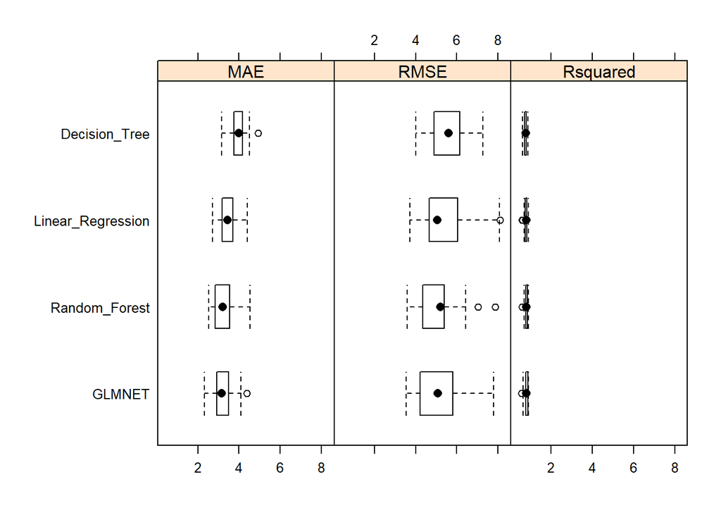

```r
bwplot(results)
```

###Hour 16

```r
lin_reg_h16 <- train(production ~ .,
                    data = weather_production_train_h16 %>% select(-date.x, -hour.x),
                    method = "lm",
                    trControl = fitControl,
                    tuneGrid = expand.grid(intercept = T),
                    tuneLength = 5)

dec_tree_h16 <- train(production ~ .,
                     data = weather_production_train_h16 %>% select(-date.x, -hour.x),
                     method = "rpart",
                     trControl = fitControl,
                     tuneGrid = expand.grid(cp = 0.01524276),
                     tuneLength = 6)

rand_forest_h16 <- train(production ~ .,
                        data = weather_production_train_h16 %>% select(-date.x, -hour.x),
                        method = "ranger",
                        trControl = fitControl,
                        num.trees = 50,
                        tuneGrid = expand.grid(mtry = 52, splitrule = "extratrees", min.node.size = 5),
                        importance = "impurity")

glmnet_h16 <- train(production ~ .,
                   data = weather_production_train_h16 %>% select(-date.x, -hour.x),
                   method = "glmnet",
                   trControl = fitControl,
                   tuneGrid = expand.grid(alpha = 0.55, lambda = 0.2097799),
                   tuneLenght= 5)

results = resamples(list(Linear_Regression = lin_reg_h16, Decision_Tree = dec_tree_h16, Random_Forest = rand_forest_h16, GLMNET = glmnet_h16))
summary(results)
```

```
##
## Call:
## summary.resamples(object = results)
##
## Models: Linear_Regression, Decision_Tree, Random_Forest, GLMNET
## Number of resamples: 25
##
## MAE
##                       Min.  1st Qu.   Median     Mean  3rd Qu.     Max. NA's
## Linear_Regression 2.383775 2.965787 3.153049 3.312560 3.665121 4.403972    0
## Decision_Tree     2.783719 3.554455 3.822662 3.890733 4.248863 5.164167    0
## Random_Forest     2.082624 2.883570 2.985000 3.030452 3.128124 3.836887    0
## GLMNET            2.687985 3.011727 3.334944 3.325895 3.641902 3.942578    0
##
## RMSE
##                       Min.  1st Qu.   Median     Mean  3rd Qu.     Max. NA's
## Linear_Regression 3.161462 4.324832 4.547082 4.766600 5.168705 6.088309    0
## Decision_Tree     3.638839 4.798335 5.381311 5.442414 6.194790 7.441709    0
## Random_Forest     3.522283 4.131066 4.461880 4.525127 4.692390 6.429027    0
## GLMNET            3.474915 4.213422 4.634654 4.598794 5.039302 5.600201    0
##
## Rsquared
##                        Min.   1st Qu.    Median      Mean   3rd Qu.      Max.
## Linear_Regression 0.7290986 0.8102168 0.8581445 0.8417656 0.8720266 0.9379787
## Decision_Tree     0.6274055 0.7429263 0.8023183 0.7918767 0.8432853 0.9043935
## Random_Forest     0.7110775 0.8448996 0.8625624 0.8577566 0.8885099 0.9161537
## GLMNET            0.7621695 0.8233171 0.8542490 0.8515088 0.8796266 0.9156294
##                   NA's
## Linear_Regression    0
## Decision_Tree        0
## Random_Forest        0
## GLMNET               0
```

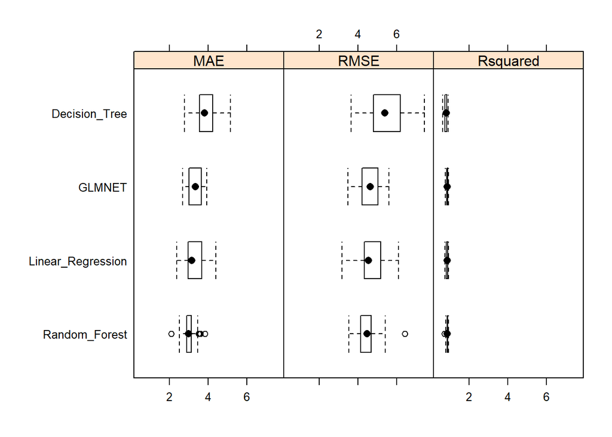

```r
bwplot(results)
```

###Hour 17

```r
lin_reg_h17 <- train(production ~ .,
                    data = weather_production_train_h17 %>% select(-date.x, -hour.x),
                    method = "lm",
                    trControl = fitControl,
                    tuneGrid = expand.grid(intercept = T),
                    tuneLength = 5)

dec_tree_h17 <- train(production ~ .,
                     data = weather_production_train_h17 %>% select(-date.x, -hour.x),
                     method = "rpart",
                     trControl = fitControl,
                     tuneGrid = expand.grid(cp = 0.01524276),
                     tuneLength = 6)

rand_forest_h17 <- train(production ~ .,
                        data = weather_production_train_h17 %>% select(-date.x, -hour.x),
                        method = "ranger",
                        trControl = fitControl,
                        num.trees = 50,
                        tuneGrid = expand.grid(mtry = 52, splitrule = "extratrees", min.node.size = 5),
                        importance = "impurity")

glmnet_h17 <- train(production ~ .,
                   data = weather_production_train_h17 %>% select(-date.x, -hour.x),
                   method = "glmnet",
                   trControl = fitControl,
                   tuneGrid = expand.grid(alpha = 0.55, lambda = 0.2097799),
                   tuneLenght= 5)

results = resamples(list(Linear_Regression = lin_reg_h17, Decision_Tree = dec_tree_h17, Random_Forest = rand_forest_h17, GLMNET = glmnet_h17))
summary(results)
```

```
##
## Call:
## summary.resamples(object = results)
##
## Models: Linear_Regression, Decision_Tree, Random_Forest, GLMNET
## Number of resamples: 25
##
## MAE
##                       Min.  1st Qu.   Median     Mean  3rd Qu.     Max. NA's
## Linear_Regression 1.733380 2.016020 2.143228 2.160047 2.265675 2.595529    0
## Decision_Tree     2.503254 2.686069 2.835654 2.908315 3.031775 3.565616    0
## Random_Forest     1.104306 1.468598 1.687416 1.609175 1.779790 1.906866    0
## GLMNET            1.850767 2.010599 2.223719 2.197502 2.332329 2.803341    0
##
## RMSE
##                       Min.  1st Qu.   Median     Mean  3rd Qu.     Max. NA's
## Linear_Regression 2.397231 2.838442 2.961427 3.049232 3.336002 3.803557    0
## Decision_Tree     3.263430 3.528352 3.783245 3.815706 4.090242 4.520934    0
## Random_Forest     1.745159 2.543281 2.692472 2.636633 2.850807 3.237821    0
## GLMNET            2.456821 2.667181 2.840824 2.931950 3.132644 3.905286    0
##
## Rsquared
##                        Min.   1st Qu.    Median      Mean   3rd Qu.      Max.
## Linear_Regression 0.8328634 0.8862731 0.9011535 0.8992810 0.9128432 0.9412236
## Decision_Tree     0.7651734 0.8234533 0.8455472 0.8410025 0.8636199 0.8989271
## Random_Forest     0.8848912 0.9140435 0.9228860 0.9237871 0.9313736 0.9673600
## GLMNET            0.8289041 0.8971044 0.9055405 0.9067946 0.9290787 0.9379857
##                   NA's
## Linear_Regression    0
## Decision_Tree        0
## Random_Forest        0
## GLMNET               0
```

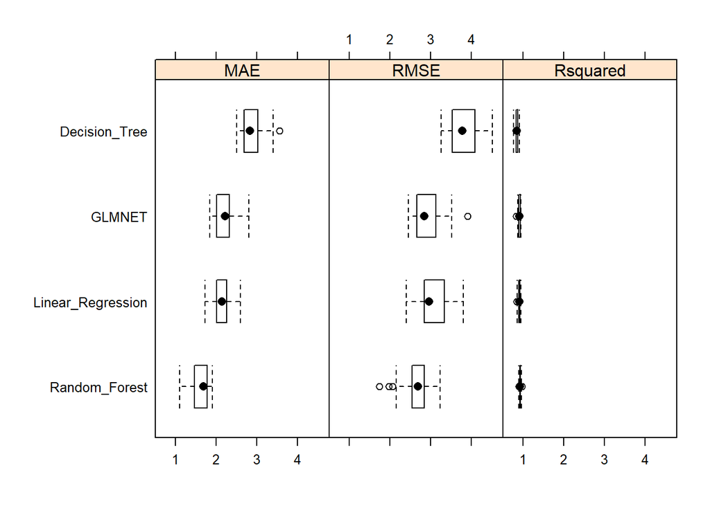

```r
bwplot(results)
```

###Hour 18

```r
lin_reg_h18 <- train(production ~ .,
                    data = weather_production_train_h18 %>% select(-date.x, -hour.x),
                    method = "lm",
                    trControl = fitControl,
                    tuneGrid = expand.grid(intercept = T),
                    tuneLength = 5)

dec_tree_h18 <- train(production ~ .,
                     data = weather_production_train_h18 %>% select(-date.x, -hour.x),
                     method = "rpart",
                     trControl = fitControl,
                     tuneGrid = expand.grid(cp = 0.01524276),
                     tuneLength = 6)

rand_forest_h18 <- train(production ~ .,
                        data = weather_production_train_h18 %>% select(-date.x, -hour.x),
                        method = "ranger",
                        trControl = fitControl,
                        num.trees = 50,
                        tuneGrid = expand.grid(mtry = 52, splitrule = "extratrees", min.node.size = 5),
                        importance = "impurity")

glmnet_h18 <- train(production ~ .,
                   data = weather_production_train_h18 %>% select(-date.x, -hour.x),
                   method = "glmnet",
                   trControl = fitControl,
                   tuneGrid = expand.grid(alpha = 0.55, lambda = 0.2097799),
                   tuneLenght= 5)

results = resamples(list(Linear_Regression = lin_reg_h18, Decision_Tree = dec_tree_h18, Random_Forest = rand_forest_h18, GLMNET = glmnet_h18))
summary(results)
```

```
##
## Call:
## summary.resamples(object = results)
##
## Models: Linear_Regression, Decision_Tree, Random_Forest, GLMNET
## Number of resamples: 25
##
## MAE
##                        Min.   1st Qu.    Median      Mean   3rd Qu.      Max.
## Linear_Regression 0.6063844 0.7214541 0.7963588 0.7949625 0.8616582 0.9666837
## Decision_Tree     0.6683282 0.8382144 1.0168487 0.9753893 1.0947982 1.2141297
## Random_Forest     0.3732244 0.4590476 0.5442742 0.5521752 0.6329896 0.7701570
## GLMNET            0.7483322 0.8112832 0.8790183 0.8823578 0.9247840 1.0378238
##                   NA's
## Linear_Regression    0
## Decision_Tree        0
## Random_Forest        0
## GLMNET               0
##
## RMSE
##                        Min.   1st Qu.   Median     Mean  3rd Qu.     Max. NA's
## Linear_Regression 0.7821686 1.0624469 1.191807 1.162007 1.284986 1.474565    0
## Decision_Tree     0.9380788 1.2422225 1.611479 1.501614 1.789189 1.862354    0
## Random_Forest     0.7116713 0.8988039 1.079612 1.089873 1.305421 1.432408    0
## GLMNET            0.9218440 1.0929089 1.253729 1.222964 1.323958 1.533497    0
##
## Rsquared
##                        Min.   1st Qu.    Median      Mean   3rd Qu.      Max.
## Linear_Regression 0.8644522 0.8954148 0.9154159 0.9157000 0.9340282 0.9618845
## Decision_Tree     0.7858253 0.8102022 0.8491912 0.8590201 0.8962599 0.9513001
## Random_Forest     0.8863766 0.8991507 0.9262789 0.9261797 0.9515032 0.9731092
## GLMNET            0.8525834 0.8987005 0.9067003 0.9098561 0.9295355 0.9479408
##                   NA's
## Linear_Regression    0
## Decision_Tree        0
## Random_Forest        0
## GLMNET               0
```

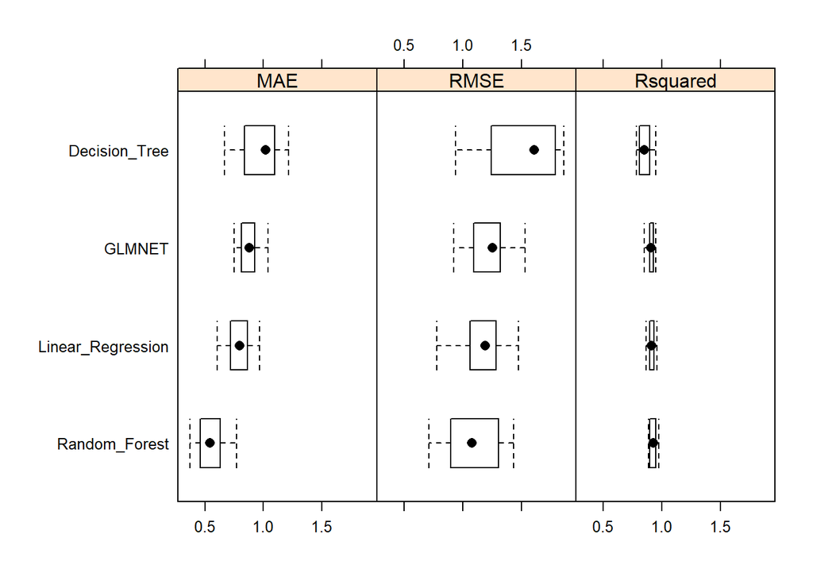

```r
bwplot(results)
```

###Hour 19

```r
lin_reg_h19 <- train(production ~ .,
                    data = weather_production_train_h19 %>% select(-date.x, -hour.x),
                    method = "lm",
                    trControl = fitControl,
                    tuneGrid = expand.grid(intercept = T),
                    tuneLength = 5)

dec_tree_h19 <- train(production ~ .,
                     data = weather_production_train_h19 %>% select(-date.x, -hour.x),
                     method = "rpart",
                     trControl = fitControl,
                     tuneGrid = expand.grid(cp = 0.01524276),
                     tuneLength = 6)

rand_forest_h19 <- train(production ~ .,
                        data = weather_production_train_h19 %>% select(-date.x, -hour.x),
                        method = "ranger",
                        trControl = fitControl,
                        num.trees = 50,
                        tuneGrid = expand.grid(mtry = 52, splitrule = "extratrees", min.node.size = 5),
                        importance = "impurity")

glmnet_h19 <- train(production ~ .,
                   data = weather_production_train_h19 %>% select(-date.x, -hour.x),
                   method = "glmnet",
                   trControl = fitControl,
                   tuneGrid = expand.grid(alpha = 0.55, lambda = 0.2097799),
                   tuneLenght= 5)

results = resamples(list(Linear_Regression = lin_reg_h19, Decision_Tree = dec_tree_h19, Random_Forest = rand_forest_h19, GLMNET = glmnet_h19))
summary(results)
```

```
##
## Call:
## summary.resamples(object = results)
##
## Models: Linear_Regression, Decision_Tree, Random_Forest, GLMNET
## Number of resamples: 25
##
## MAE
##                         Min.    1st Qu.     Median       Mean   3rd Qu.
## Linear_Regression 0.12002812 0.15152001 0.17020468 0.17078813 0.1848431
## Decision_Tree     0.09568686 0.11394577 0.12221981 0.13202968 0.1592327
## Random_Forest     0.05729474 0.06509658 0.08292745 0.08503212 0.1000003
## GLMNET            0.13752427 0.18445094 0.20008661 0.20233791 0.2213257
##                        Max. NA's
## Linear_Regression 0.2314436    0
## Decision_Tree     0.1787483    0
## Random_Forest     0.1370770    0
## GLMNET            0.2764206    0
##
## RMSE
##                        Min.   1st Qu.    Median      Mean   3rd Qu.      Max.
## Linear_Regression 0.1663733 0.2026474 0.2387667 0.2624271 0.2634080 0.4167099
## Decision_Tree     0.1638091 0.1952208 0.2265736 0.2483289 0.2760300 0.4051128
## Random_Forest     0.1182768 0.1375434 0.1695819 0.2041448 0.2293130 0.3804869
## GLMNET            0.1888814 0.2792740 0.3066353 0.3148512 0.3397703 0.4659062
##                   NA's
## Linear_Regression    0
## Decision_Tree        0
## Random_Forest        0
## GLMNET               0
##
## Rsquared
##                        Min.   1st Qu.    Median      Mean   3rd Qu.      Max.
## Linear_Regression 0.5799193 0.8191570 0.8543380 0.8197018 0.8920033 0.9294351
## Decision_Tree     0.6333659 0.7770090 0.8679884 0.8366763 0.9038854 0.9373055
## Random_Forest     0.6672166 0.8734236 0.9206878 0.8854836 0.9491163 0.9600712
## GLMNET            0.6390925 0.7662747 0.8169792 0.7982082 0.8397059 0.9051359
##                   NA's
## Linear_Regression    0
## Decision_Tree        0
## Random_Forest        0
## GLMNET               0
```

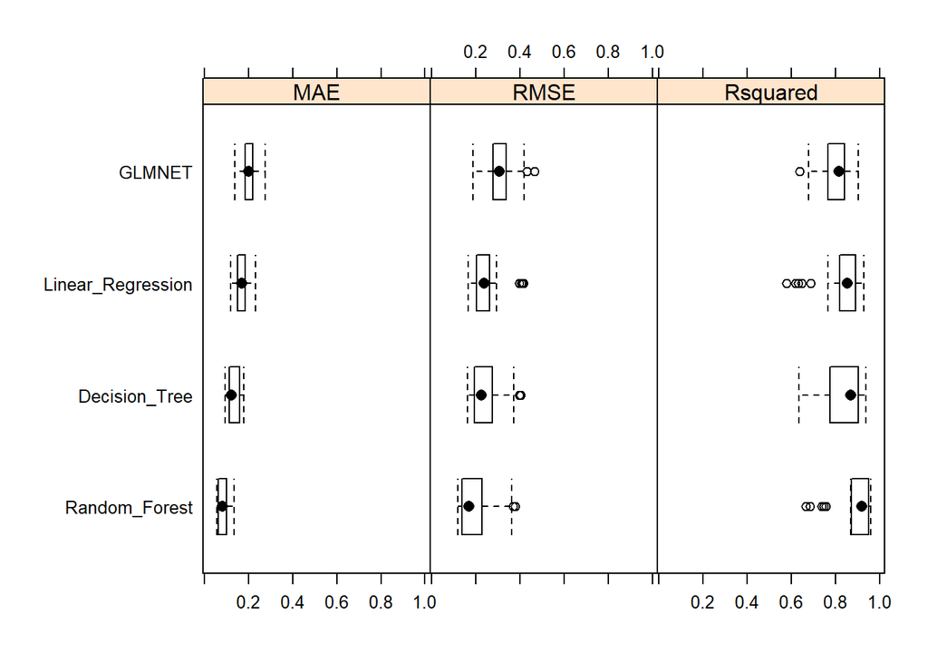

```r
bwplot(results)
```

#Prediction for the Test Period

As Random Forest model is generally the best one according to the model comparison results among hourly models, we choose to continue with Random Forest model to make the predictions on the test set. Below the predictions are done.

```r
rf_h5_pred_test <- predict(rand_forest_h5$finalModel, data = weather_production_test_h5)
rf_h6_pred_test <- predict(rand_forest_h6$finalModel, data = weather_production_test_h6)
rf_h7_pred_test <- predict(rand_forest_h7$finalModel, data = weather_production_test_h7)
rf_h8_pred_test <- predict(rand_forest_h8$finalModel, data = weather_production_test_h8)
rf_h9_pred_test <- predict(rand_forest_h9$finalModel, data = weather_production_test_h9)
rf_h10_pred_test <- predict(rand_forest_h10$finalModel, data = weather_production_test_h10)
rf_h11_pred_test <- predict(rand_forest_h11$finalModel, data = weather_production_test_h11)
rf_h12_pred_test <- predict(rand_forest_h12$finalModel, data = weather_production_test_h12)
rf_h13_pred_test <- predict(rand_forest_h13$finalModel, data = weather_production_test_h13)
rf_h14_pred_test <- predict(rand_forest_h14$finalModel, data = weather_production_test_h14)
rf_h15_pred_test <- predict(rand_forest_h15$finalModel, data = weather_production_test_h15)
rf_h16_pred_test <- predict(rand_forest_h16$finalModel, data = weather_production_test_h16)
rf_h17_pred_test <- predict(rand_forest_h17$finalModel, data = weather_production_test_h17)
rf_h18_pred_test <- predict(rand_forest_h18$finalModel, data = weather_production_test_h18)
rf_h19_pred_test <- predict(rand_forest_h19$finalModel, data = weather_production_test_h19)
```

Test set predictions are binded with test data set for each hour.

```r
df4_test_h5_w_pred <- weather_production_test_h5 %>% select(date.x, hour.x, production) %>% mutate(Prediction = rf_h5_pred_test$predictions)
df4_test_h6_w_pred <- weather_production_test_h6 %>% select(date.x, hour.x, production) %>% mutate(Prediction = rf_h6_pred_test$predictions)
df4_test_h7_w_pred <- weather_production_test_h7 %>% select(date.x, hour.x, production) %>% mutate(Prediction = rf_h7_pred_test$predictions)
df4_test_h8_w_pred <- weather_production_test_h8 %>% select(date.x, hour.x, production) %>% mutate(Prediction = rf_h8_pred_test$predictions)
df4_test_h9_w_pred <- weather_production_test_h9 %>% select(date.x, hour.x, production) %>% mutate(Prediction = rf_h9_pred_test$predictions)
df4_test_h10_w_pred <- weather_production_test_h10 %>% select(date.x, hour.x, production) %>% mutate(Prediction = rf_h10_pred_test$predictions)
df4_test_h11_w_pred <- weather_production_test_h11%>% select(date.x, hour.x, production) %>% mutate(Prediction = rf_h11_pred_test$predictions)
df4_test_h12_w_pred <- weather_production_test_h12 %>% select(date.x, hour.x, production) %>% mutate(Prediction = rf_h12_pred_test$predictions)
df4_test_h13_w_pred <- weather_production_test_h13 %>% select(date.x, hour.x, production) %>% mutate(Prediction = rf_h13_pred_test$predictions)
df4_test_h14_w_pred <- weather_production_test_h14 %>% select(date.x, hour.x, production) %>% mutate(Prediction = rf_h14_pred_test$predictions)
df4_test_h15_w_pred <- weather_production_test_h15 %>% select(date.x, hour.x, production) %>% mutate(Prediction = rf_h15_pred_test$predictions)
df4_test_h16_w_pred <- weather_production_test_h16 %>% select(date.x, hour.x, production) %>% mutate(Prediction = rf_h16_pred_test$predictions)
df4_test_h17_w_pred <- weather_production_test_h17 %>% select(date.x, hour.x, production) %>% mutate(Prediction = rf_h17_pred_test$predictions)
df4_test_h18_w_pred <- weather_production_test_h18 %>% select(date.x, hour.x, production) %>% mutate(Prediction = rf_h18_pred_test$predictions)
df4_test_h19_w_pred <- weather_production_test_h19 %>% select(date.x, hour.x, production) %>% mutate(Prediction = rf_h19_pred_test$predictions)
```

Test sets for each hour with predictions are row binded. Thus, we create one test set with prediction for whole data.

```r
df4_test_w_pred <- rbind(df4_test_h5_w_pred, df4_test_h6_w_pred, df4_test_h7_w_pred, df4_test_h8_w_pred,
                         df4_test_h9_w_pred, df4_test_h10_w_pred, df4_test_h11_w_pred, df4_test_h12_w_pred,
                         df4_test_h13_w_pred, df4_test_h14_w_pred, df4_test_h15_w_pred, df4_test_h16_w_pred,
                         df4_test_h17_w_pred, df4_test_h18_w_pred, df4_test_h19_w_pred) %>% arrange(date.x, hour.x)
head(df4_test_w_pred,15)
```

```
##         date.x hour.x production  Prediction
##  1: 2022-01-01      5      0.000  0.00000000
##  2: 2022-01-01      6      0.000  0.00000000
##  3: 2022-01-01      7      0.000  0.01125133
##  4: 2022-01-01      8      3.937  4.97316900
##  5: 2022-01-01      9     22.082 16.67280400
##  6: 2022-01-01     10     29.388 29.23062433
##  7: 2022-01-01     11     32.253 27.79684700
##  8: 2022-01-01     12     30.557 28.83879533
##  9: 2022-01-01     13     30.553 24.77573800
## 10: 2022-01-01     14     31.245 27.96274595
## 11: 2022-01-01     15     27.089 21.01891567
## 12: 2022-01-01     16     12.915  8.40537800
## 13: 2022-01-01     17      1.388  0.75338300
## 14: 2022-01-01     18      0.000  0.00000000
## 15: 2022-01-01     19      0.000  0.00000000
```

```r
skim(df4_test_w_pred %>% select(production, Prediction))
```

Data summary

| Name | df4_test_w_pred %>% selec… |
| --- | --- |
| Number of rows | 855 |
| Number of columns | 2 |
| Key | NULL |
| _______________________ |  |
| Column type frequency: |  |
| numeric | 2 |
| ________________________ |  |
| Group variables | None |

**Variable type: numeric**

| skim_variable | n_missing | complete_rate | mean | sd | p0 | p25 | p50 | p75 | p100 | hist |
| --- | --- | --- | --- | --- | --- | --- | --- | --- | --- | --- |
| production | 0 | 1 | 11.66 | 13.22 | 0 | 0.00 | 5.14 | 24.66 | 34.80 | ▇▂▁▁▃ |
| Prediction | 0 | 1 | 10.10 | 11.25 | 0 | 0.05 | 5.47 | 17.88 | 33.38 | ▇▂▁▁▂ |

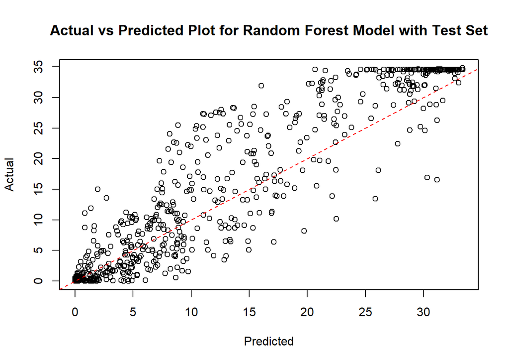

```r
plot(df4_test_w_pred$Prediction, df4_test_w_pred$production, xlab = "Predicted", ylab = "Actual", main = "Actual vs Predicted Plot for Random Forest Model with Test Set")
abline(a=0,b=1,col='red', lty = 2)
```

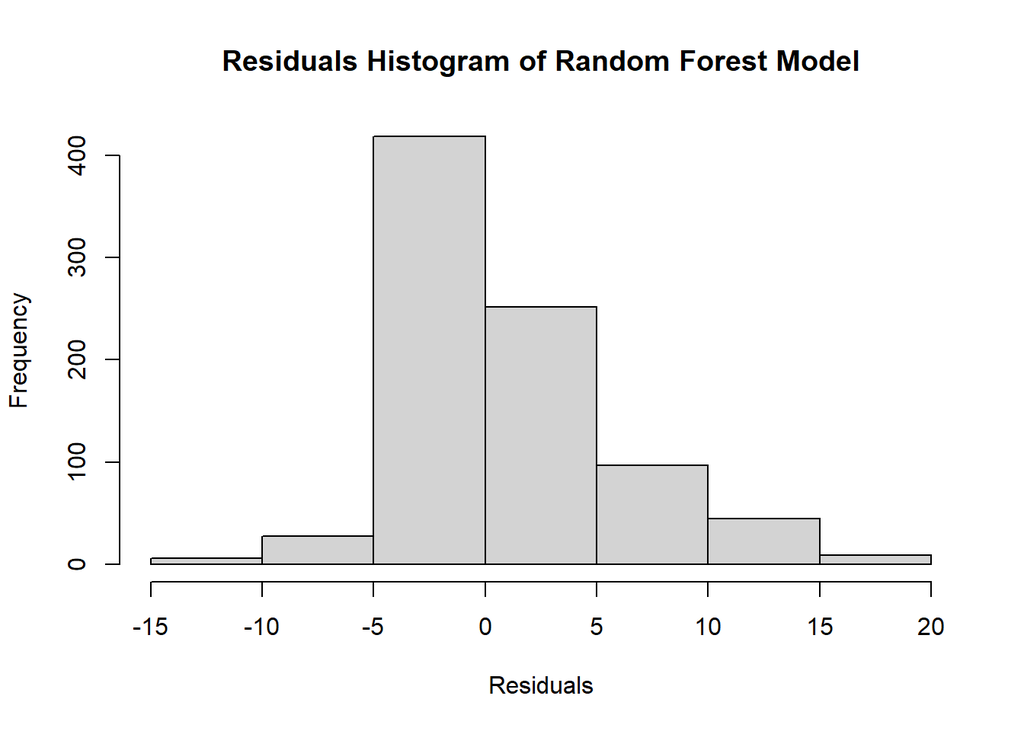

```r
rf_residuals_test <- df4_test_w_pred$production - df4_test_w_pred$Prediction
hist(rf_residuals_test, xlab = "Residuals", main = "Residuals Histogram of Random Forest Model")
```

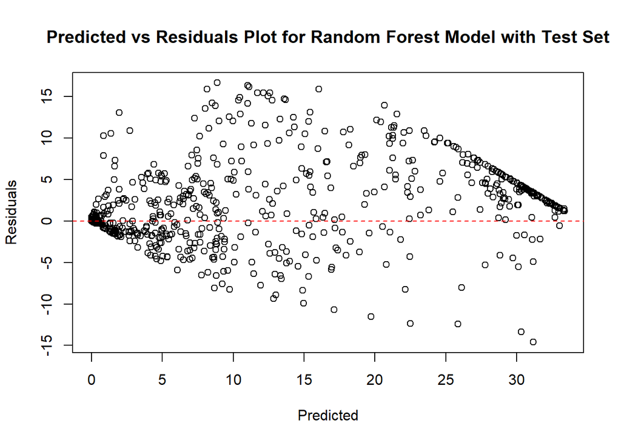

```r
plot(df4_test_w_pred$Prediction, rf_residuals_test, xlab = "Predicted", ylab = "Residuals", main = "Predicted vs Residuals Plot for Random Forest Model with Test Set")
abline(h = 0, col = "red", lty = 2)
```

Lastly, RMSE values of test set predictions are shown. It is not a high value which is also good for the model.

```r
RMSE(df4_test_w_pred$production, df4_test_w_pred$Prediction)
```

```
## [1] 4.729403
```

**Possible extensions to have a better approach**

1. Relation between independent variables can be count into concept as correlation analysis.
2. Coordinate based analysis caan be done to predict the production in a detailed manner
3. It can be check whether there is any other independent variable to put in the model besides of these four.